# Single-cell RNA-seq Analysis Report

## 3. **Normalization**:

Data was normalized using SCTransform.

## 4. **Dimensionality Reduction**:

PCA was performed, 25 PCs were used for creating a UMAP.

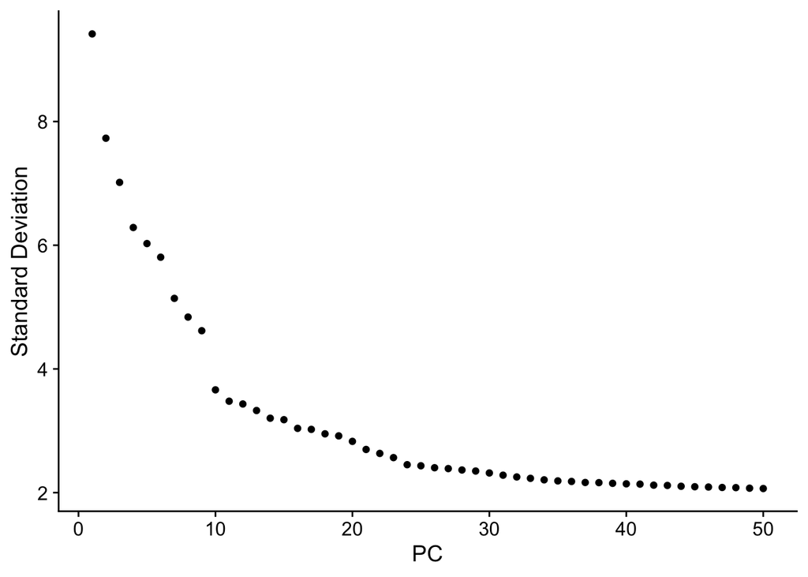

```r
dat <- readRDS("02_objects/Seurat_DR.rds")

# PCA

ElbowPlot(dat,ndims = 50)
```

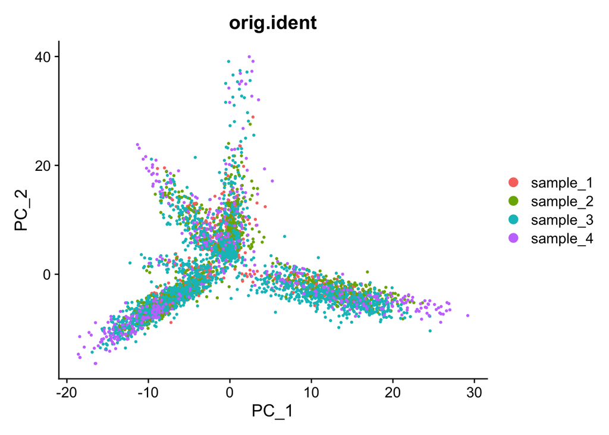

```r
DimPlot(object = dat, reduction = "pca", group.by = "orig.ident")
```

## 5. **Clustering**:

Cells were clustered using the Louvain algorithm, and UMAP dimension reduction.

## (Optional) 5.B. **Integration**:

Data was integrated using the CCA method and PCA and UMAP dimnalitiy reduction redone.

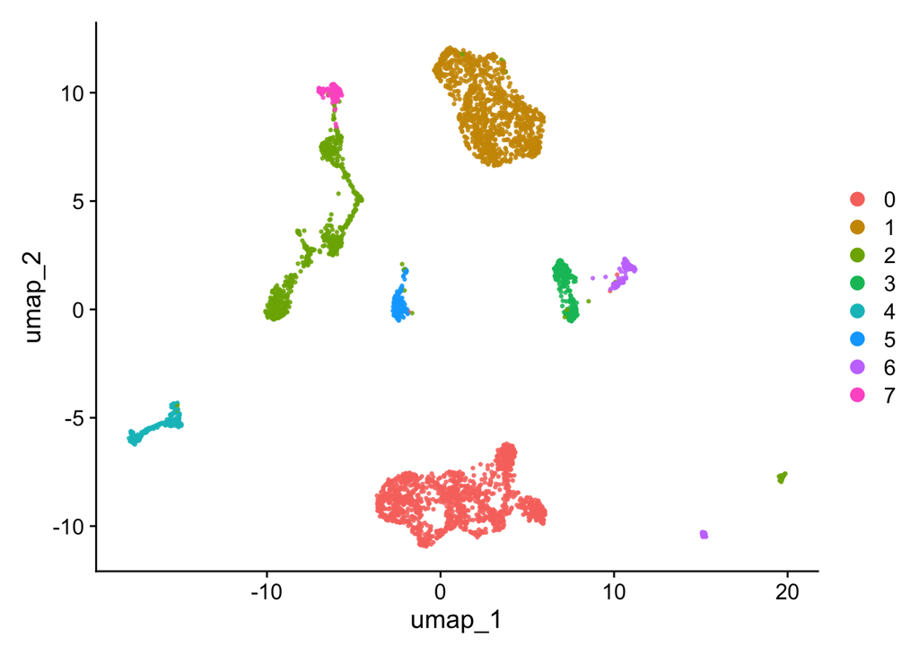

```r
# UMAP

DimPlot(dat, alpha = 0.8, reduction = "umap")
```

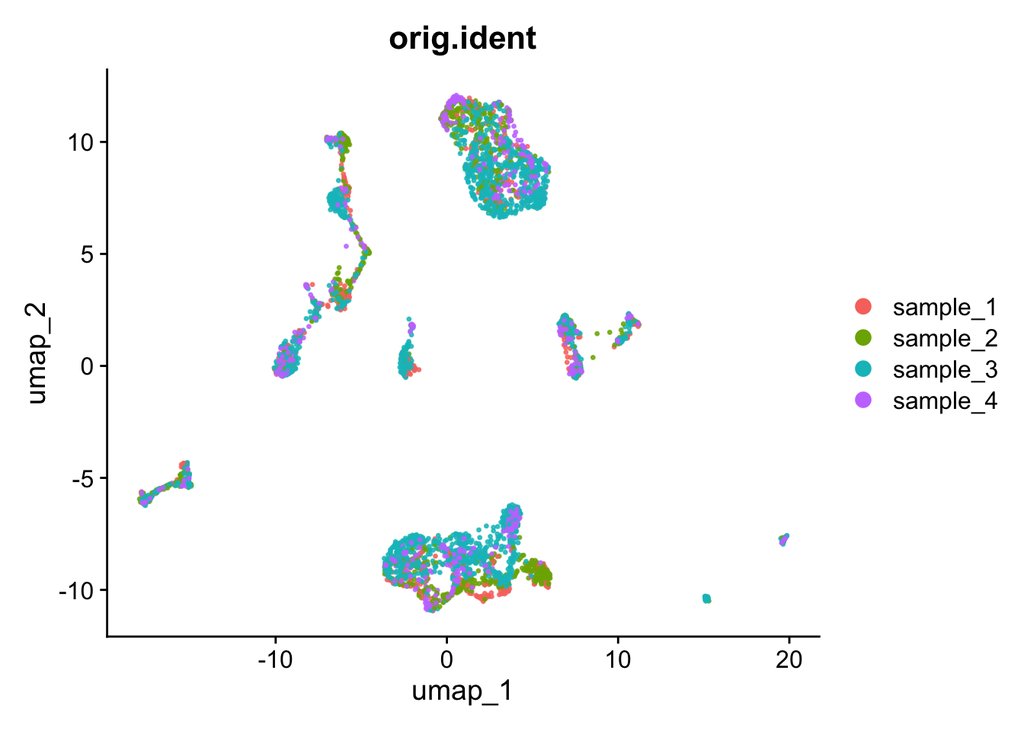

```r
DimPlot(dat, group.by="orig.ident", alpha = 0.8, reduction = "umap")
```

### **Markers**:

Gene markers for each cluster were identified.

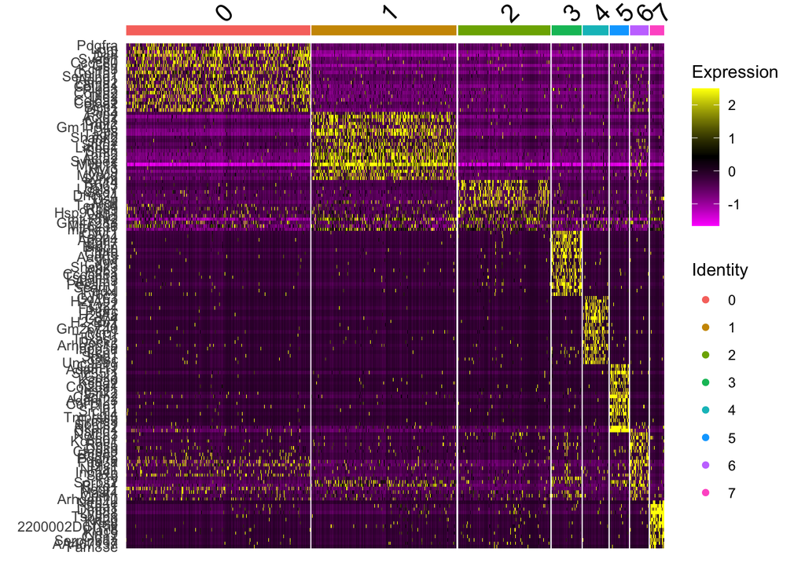

```r
dat <- readRDS("02_objects/Seurat_DR.rds")
dat_markers <- readRDS("02_objects/markers.rds")

# Heatmap
top20 <- dat_markers %>% group_by(cluster) %>% slice_max(order_by = avg_log2FC, n = 20)
DoHeatmap(
  object = dat,
  features = top20$gene)
```

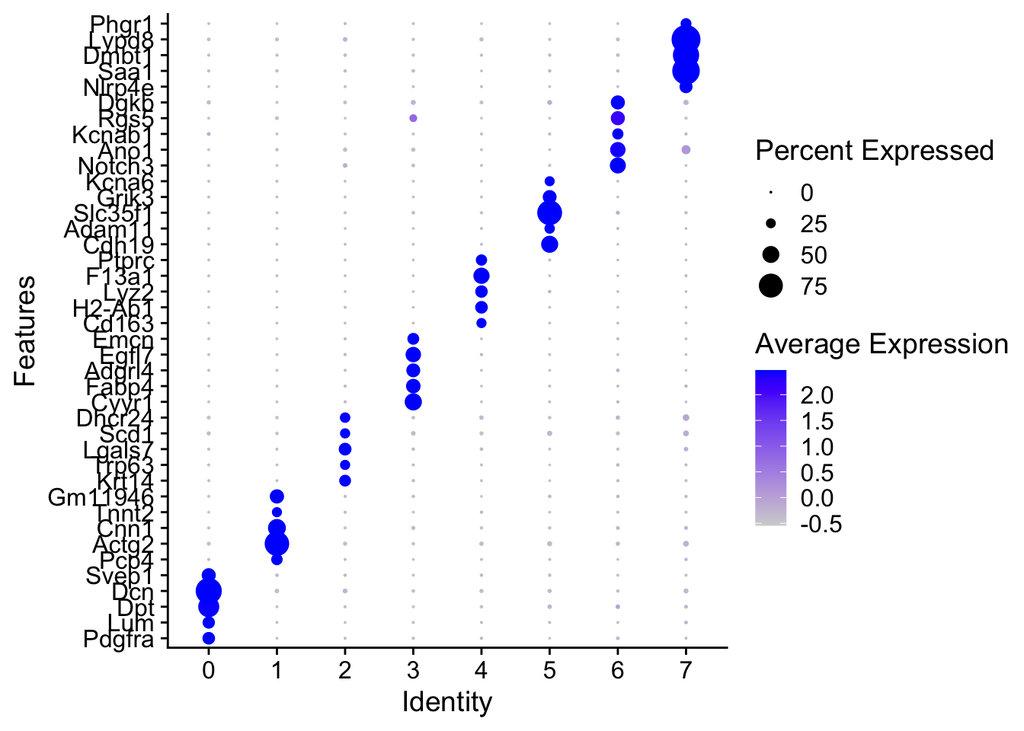

```r
top5 <- dat_markers %>% group_by(cluster) %>% slice_max(order_by = avg_log2FC, n = 5)
to_plot <- unique(top5$gene)
DotPlot(dat, features = to_plot, group.by = "SCT_snn_res.0.1") + coord_flip()
```

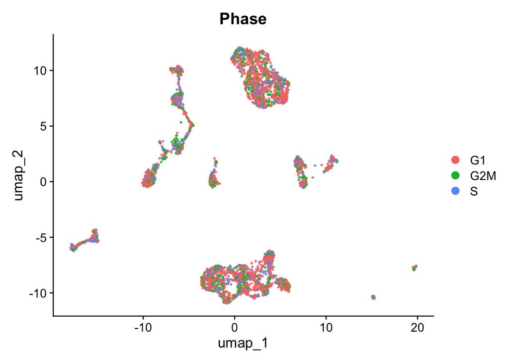

```r
dat <- readRDS("02_objects/Seurat_CellType.rds")

# Cell Phase
DimPlot(dat, alpha = 0.8, group.by = "Phase")
```

## 6. **Cell Type Annotation**:

Cells were annotated using the scMRMA package, which provides tools for automated cell type annotation in single-cell RNA-seq data. For more details, visit the [scMRMA documentation](https://academic.oup.com/nar/article/50/2/e7/6396893).

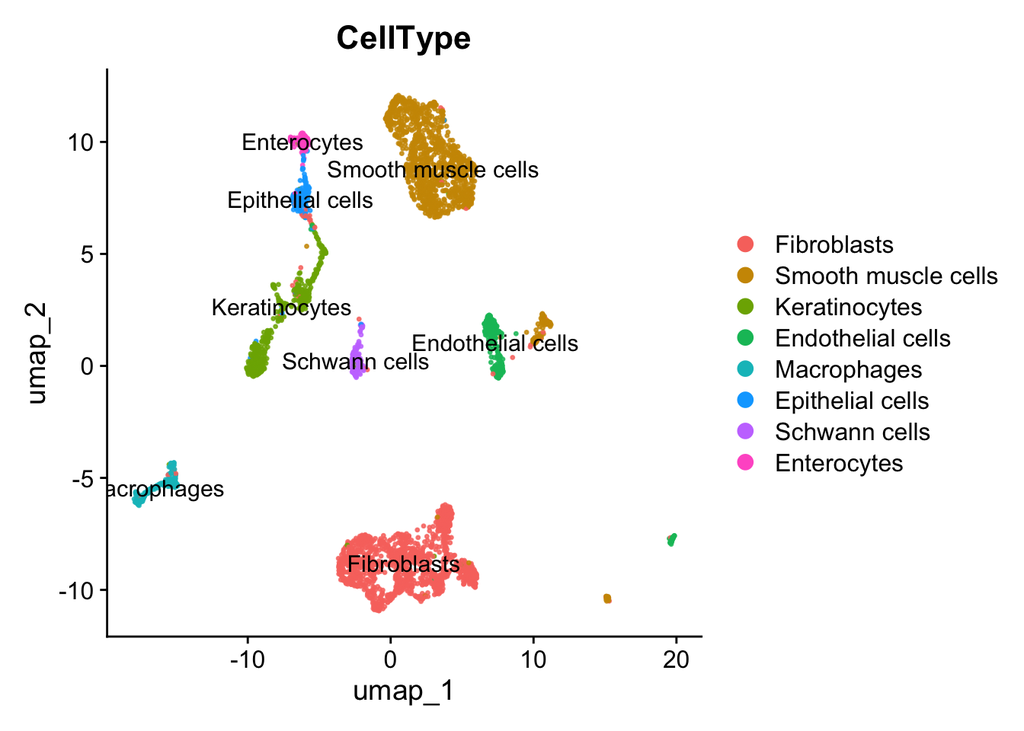

```r
DimPlot(dat, alpha = 0.8, group.by = "CellType", label=T)
```

## 7. **Differential Expression Analysis**:

DE analysis was performed using the FindMarkers function in Seurat.

```r
results <- readRDS("02_objects/results.rds")

head(results$comparisons[[1]], 30)
```

```
##                 p_val avg_log2FC pct.1 pct.2    p_val_adj
## Xist     2.125309e-93  5.3686704 0.467 0.021 5.509438e-89
## C7       1.230204e-39 -6.4847887 0.024 0.313 3.189057e-35
## Gm48099  1.715215e-27  0.8030896 0.886 0.786 4.446352e-23
## Thsd7a   1.311742e-26 -2.3377745 0.065 0.306 3.400430e-22
## Hexb     1.736996e-26  1.7086913 0.667 0.508 4.502816e-22
## Cdk8     6.864165e-26  0.9242649 0.985 0.946 1.779398e-21
## Slit3    6.661613e-24 -1.2072481 0.372 0.627 1.726890e-19
## Arhgap24 5.423928e-23 -2.0579707 0.218 0.463 1.406045e-18
## Egfr     1.284453e-19 -1.6202875 0.184 0.415 3.329688e-15
## Camk1d   2.120138e-16  1.1254989 0.754 0.653 5.496035e-12
## Gria3    4.274109e-16 -1.4134660 0.181 0.380 1.107977e-11
## Vcan     2.667257e-15 -1.2005591 0.115 0.297 6.914331e-11
## Zbtb16   1.197939e-14 -1.0184508 0.214 0.419 3.105418e-10
## Cdh13    1.959679e-13 -1.9027624 0.188 0.360 5.080077e-09
## Mir6236  3.483923e-13  0.7074540 0.818 0.743 9.031373e-09
## Pid1     8.556782e-13 -0.9533667 0.460 0.637 2.218175e-08
## Zbtb20   2.190182e-12 -0.5623300 0.700 0.820 5.677609e-08
## Ccdc80   3.302191e-12 -1.1954722 0.242 0.417 8.560269e-08
## Auts2    1.729743e-11 -0.9667419 0.479 0.629 4.484012e-07
## Fmo2     2.360334e-11 -1.4977102 0.158 0.316 6.118694e-07
## Abca8a   7.221480e-11 -1.4922380 0.119 0.258 1.872024e-06
## Tshz2    8.921484e-11 -0.7435391 0.622 0.741 2.312716e-06
## Plcb4    1.176707e-10 -0.7294037 0.333 0.503 3.050378e-06
## Boc      1.544979e-10 -1.6194590 0.114 0.252 4.005049e-06
## Bicc1    1.614024e-10 -0.9711653 0.365 0.517 4.184035e-06
## Sema5a   3.079173e-10 -0.9493084 0.158 0.310 7.982140e-06
## Inmt     5.613907e-10 -0.5676623 0.110 0.251 1.455293e-05
## Col1a1   7.600122e-10  1.0684432 0.708 0.653 1.970180e-05
## Crispld2 2.101231e-09 -1.0607463 0.207 0.356 5.447022e-05
## Ltbp1    2.205964e-09 -1.1614576 0.147 0.283 5.718520e-05
```